# Лабораторная по многомерной статистике

Дмитрий Пасько

## Описание

Для выполнения работы использовался язык **R** версии 3.6.1. Необходимые пакеты скачиваются командой

```r
install.packages(c("readxl", "dplyr", "ggplot2", "ggpubr", "corrplot", "psych",
    "MASS", "tree", "randomForest", "TeachingDemos", "mice", "corrgram", "magrittr",
    "plotly", "factoextra"))
```

и подключаются

```r
library(readxl)  #чтение из excel
library(dplyr)  #современные средства программирования, включая функциональное
library(ggplot2)  #красивые удобные графики
library(ggpubr)  #группировка изображений
library(corrplot)  #картинка для корреляционной матрицы
library(psych)  #факторный анализ
library(MASS)  #линейный дискриминантный анализ
library(tree)  #визуализация деревьев
library(randomForest)  #случайные леса
library(TeachingDemos)  #пиктограммы
library(mice)  #обработка отсутствующих значений
library(corrgram)  #коррелограммы
library(magrittr)  #конвеерный оператор
library(plotly)  #интерактивная графика
library(factoextra)  #графика по главным компонентам
```

Также использовался номер варианта

```r
nv = 7  #номер варианта
```

Дополнительная информация: [сайт по статистике в R](http://www.sthda.com/english/), [огромная статья по построению моделей в R](https://ranalytics.github.io/data-mining/01-Data-Mining-Models-in-R.html), [cтатья по кластерному, факторному и дискриминантному анализу в R](https://rpubs.com/iezepov/e502lec7), [курс по анализу данных в R](https://stepik.org/course/129/syllabus), [курс по основам R как языка программирования](https://stepik.org/course/497/syllabus), [курс по статистике в R](https://stepik.org/course/524/syllabus), [перечень основых функций языка](https://aakinshin.net/ru/posts/r-functions/), [математические операции в R](https://ru.wikibooks.org/wiki/Язык_программирования_R/Математика), [книги по R на моём GitHub](https://github.com/PasaOpasen/LittleHelps/tree/master/книги%20по%20языкам/R), [набор ссылок](https://ru.stackoverflow.com/questions/506597/Книги-и-учебные-ресурсы-по-языку-r), [отличный сайт по R](https://www.statmethods.net).

## Многомерный анализ

### Задание 1

Подготовим данные:

```r
datacrude = data.frame(read_excel("Таблица 1.xlsx"))  #считывание таблицы
data = datacrude[5:nrow(datacrude), -1]  #удаление лишних строк и столбцов
data = data[-nv, ]  #удаление строки в соответствиии с номером варианта
colnames(data) = c("Country", "Doctors", "Deaths", "GDP", "Costs")  #переименование столбцов (для лаконичности)
data[, 1] = factor(data[, 1])  #первая переменная из количественной преобразуется в номенативную
row.names(data) = as.character(1:nrow(data))  #наблюдения нумеруются

data %>% tbl_df()  #таблица старого образца переводится в более удобный и выводится
```

| Country | Doctors | Deaths | GDP | Costs |
| --- | --- | --- | --- | --- |
| Россия | 44.5 | 84.98 | 20.399999999999999 | 3.2 |
| Австралия | 32.5 | 30.58 | 71.400000000000006 | 8.5 |
| Австрия | 33.9 | 38.42 | 78.7 | 9.1999999999999993 |
| Азербайджан | 38.799999999999997 | 60.34 | 12.1 | 3.3 |
| Армения | 34.4 | 60.22 | 10.9 | 3.2 |
| Беларусь | 43.6 | 60.79 | 20.399999999999999 | 5.4 |
| Болгария | 36.4 | 70.569999999999993 | 17.3 | 5.4 |
| Великобритания | 17.899999999999999 | 34.51 | 69.7 | 7.1 |
| Венгрия | 32.1 | 64.73 | 24.5 | 6 |
| Германия | 38.1 | 36.630000000000003 | 76.2 | 8.6 |

[output cut: 9 more lines]

```r
data[, 2:5] = apply(data[, 2:5], 2, function(x) scale(as.numeric(x)))  #тут переменные из текста преобразуются в числа и стандартизируются
```

Полученная таблица (**стандартизованные данные**):

```r
data %>% tbl_df()
```

| Country | Doctors | Deaths | GDP | Costs |
| --- | --- | --- | --- | --- |
| Россия | 0.868971899 | 2.0605655 | -0.80673810 | -1.24613305 |
| Австралия | -0.408433600 | -0.9919929 | 0.98088874 | 1.06058751 |
| Австрия | -0.259402959 | -0.5520653 | 1.23676474 | 1.36524871 |
| Азербайджан | 0.262204287 | 0.6779361 | -1.09766560 | -1.20261003 |
| Армения | -0.206177730 | 0.6712025 | -1.13972741 | -1.24613305 |
| Беларусь | 0.773166486 | 0.7031871 | -0.80673810 | -0.28862641 |
| Болгария | 0.006723187 | 1.2519742 | -0.91539777 | -0.28862641 |
| Великобритания | -1.962610291 | -0.7714680 | 0.92130118 | 0.45126510 |
| Венгрия | -0.451013784 | 0.9242731 | -0.66302692 | -0.02748823 |
| Германия | 0.187688966 | -0.6525080 | 1.14913597 | 1.10411054 |

[output cut: 9 more lines]

**Средние и стандартные отклонения**:

```r
means = apply(data[, -1], 1, mean)
sds = apply(data[, -1], 1, sd)
data_frame(countries = data[, 1], means, sds)
```

| countries | means | sds |
| --- | --- | --- |
| Россия | 0.21916657 | 1.5288973 |
| Австралия | 0.16026244 | 1.0222720 |
| Австрия | 0.44763629 | 0.9939893 |
| Азербайджан | -0.34003380 | 0.9516647 |
| Армения | -0.48020891 | 0.8986000 |
| Беларусь | 0.09524726 | 0.7724640 |
| Болгария | 0.01366831 | 0.9106766 |
| Великобритания | -0.34037800 | 1.2956349 |
| Венгрия | -0.05431396 | 0.7038595 |
| Германия | 0.44710687 | 0.8565335 |

[output cut: 9 more lines]

Для решения задачи создается **матрица (евклидовых) расстояний**

```r
(d = dist(data[, 2:5], method = "euclidean"))  #матрица расстояний
```

```
##            1         2         3         4         5         6         7
## 2  4.4120797
## 3  4.3697012 0.6115859
## 4  1.5382991 3.5610208 3.7186612
## 5  1.7880599 3.5531815 3.7371442 0.4723246
## 6  1.6638732 3.0472614 3.0908033 1.0870717 1.4099074
## 7  1.5250963 3.2594515 3.2699370 1.1240009 1.1617940 0.9488992
## 8  4.6803367 1.6849098 1.9707704 3.7231844 3.5064730 3.6321676 3.4486947
## 9  2.1305565 2.7495920 2.7866134 1.4625949 1.3551118 1.2791960 0.6699219
## 10 4.1441528 0.7076818 0.5346512 3.4849263 3.5594776 2.8188389 3.1403530
## 11 3.2486216 1.8206319 2.1256680 2.1992479 2.3440153 1.7984619 2.3867169
## 12 1.7145100 4.2598610 4.3159864 1.7317365 2.2010009 1.5063236 2.2014486
## 13 3.9266511 0.9626679 1.1543992 3.1534712 3.2038842 2.7121034 3.0370283
## 14 4.4585820 2.0655695 2.3403208 3.4726012 3.1990304 3.4902301 3.1859046
## 15 3.8527282 1.1937521 1.5010755 2.9190773 3.0342823 2.3476421 2.8678297
## 16 4.2780349 1.7992641 1.7544006 3.6966667 3.9110938 2.9014521 3.5410103
## 17 1.1516395 3.7772898 3.8710270 0.4959369 0.6400378 1.2052633 0.9456070
## 18 5.2950469 0.9960504 1.0830876 4.4639940 4.4123030 3.9438542 4.0589639
## 19 2.1800493 3.3145362 3.5576672 0.7224496 0.4269473 1.5073417 1.3700879
##            8         9        10        11        12        13        14
## 2
## 3
## 4
## 5
## 6
## 7
## 8
## 9  2.8106515
## 10 2.2618696 2.7310492
## 11 2.7345527 2.1695599 1.7354273
## 12 4.9733098 2.7118614 3.9329969 2.6691311
## 13 2.0363879 2.6398079 0.8589113 1.3939745 3.7375233
## 14 0.5914261 2.5381635 2.6064969 2.8282744 4.8619004 2.3749627
## 15 2.5278567 2.5431818 1.0871038 0.8260148 3.3153464 1.0481624 2.7533921
## 16 3.4174312 3.3313885 1.2636674 1.7764577 3.5961051 1.5965054 3.7338925
## 17 3.8739706 1.4137608 3.6706682 2.5551808 1.8380458 3.3737126 3.5987458
## 18 1.8095780 3.4938982 1.4651779 2.7833382 5.2109929 1.8695011 2.2686056
## 19 3.2468663 1.3911303 3.3826377 2.1055139 2.3815860 3.0044314 2.9454487
##           15        16        17        18
## 2
## 3
## 4
## 5
## 6
## 7
## 8
## 9
## 10
## 11
## 12
## 13
## 14
## 15
## 16 1.2122349
## 17 3.2265303 3.9414781
## 18 2.0977766 2.4660759 4.6574785
## 19 2.7937204 3.7553911 1.0377559 4.1630214
```

```r
fit <- hclust(d, method = "ward.D")
```

**Дендрограмма полученной кластеризации**:

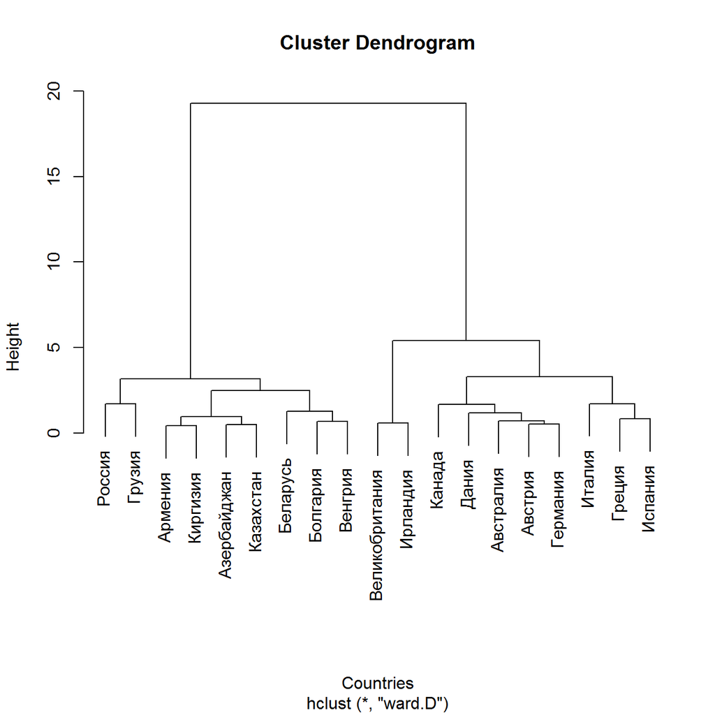

```r
plot(fit, labels = data$Country, xlab = "Countries")
```

**сумма внутригрупповых расстояний** по мере объединения кластеров:

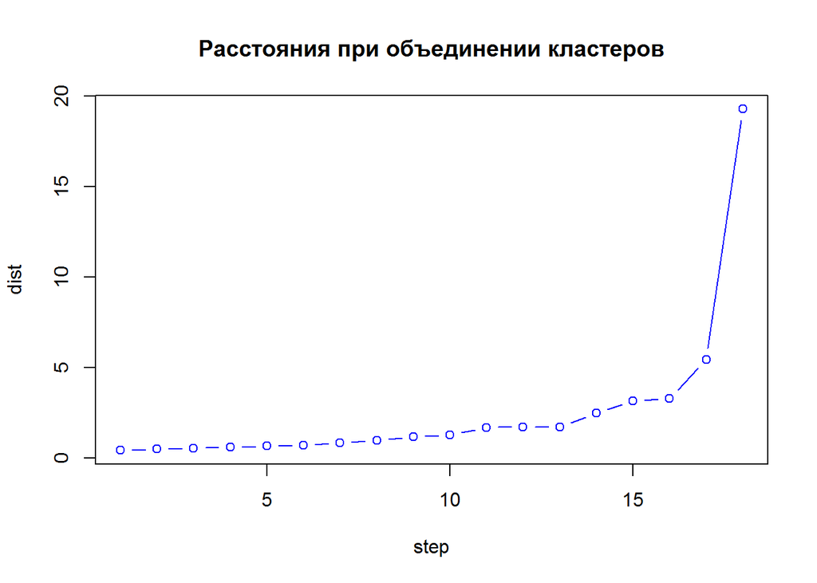

```r
plot(fit$height, xlab = "step", ylab = "dist", type = "b", col = "blue", lwd = 1,
    main = "Расстояния при объединении кластеров")
```

**Схема объединения** по шагам:

```r
mat = fit$merge
resu = list()
countries = as.character(data$Country)
for (i in 1:nrow(mat)) {

    if (mat[i, 1] < 0) {
        a = countries[-mat[i, 1]]
    } else {
        a = as.character(resu[[mat[i, 1]]])
    }

    if (mat[i, 2] < 0) {
        b = countries[-mat[i, 2]]
    } else {
        b = as.character(resu[[mat[i, 2]]])
    }

    resu[[i]] = c(a, b)
}
names(resu) = paste("Шаг", 1:nrow(mat), "расстояние", fit$height)
print(resu)
```

```
## $`Шаг 1 расстояние 0.426947302377`
## [1] "Армения"  "Киргизия"
##
## $`Шаг 2 расстояние 0.495936862326806`
## [1] "Азербайджан" "Казахстан"
##
## $`Шаг 3 расстояние 0.534651158339984`
## [1] "Австрия"  "Германия"
##
## $`Шаг 4 расстояние 0.59142613070119`
## [1] "Великобритания" "Ирландия"
##
## $`Шаг 5 расстояние 0.669921900930876`
## [1] "Болгария" "Венгрия"
##
## $`Шаг 6 расстояние 0.701294749091246`
## [1] "Австралия" "Австрия"   "Германия"
##
## $`Шаг 7 расстояние 0.826014818116822`
## [1] "Греция"  "Испания"
##
## $`Шаг 8 расстояние 0.974841826914247`
## [1] "Армения"     "Киргизия"    "Азербайджан" "Казахстан"
##
## $`Шаг 9 расстояние 1.17900272101096`
## [1] "Дания"     "Австралия" "Австрия"   "Германия"
##
## $`Шаг 10 расстояние 1.26208946988791`
## [1] "Беларусь" "Болгария" "Венгрия"
##
## $`Шаг 11 расстояние 1.68253703237057`
## [1] "Канада"    "Дания"     "Австралия" "Австрия"   "Германия"
##
## $`Шаг 12 расстояние 1.71451000628185`
## [1] "Россия" "Грузия"
##
## $`Шаг 13 расстояние 1.71712349824102`
## [1] "Италия"  "Греция"  "Испания"
##
## $`Шаг 14 расстояние 2.49230286327314`
## [1] "Армения"     "Киргизия"    "Азербайджан" "Казахстан"   "Беларусь"
## [6] "Болгария"    "Венгрия"
##
## $`Шаг 15 расстояние 3.16150026414533`
## [1] "Россия"      "Грузия"      "Армения"     "Киргизия"    "Азербайджан"
## [6] "Казахстан"   "Беларусь"    "Болгария"    "Венгрия"
##
## $`Шаг 16 расстояние 3.29068732365053`
## [1] "Канада"    "Дания"     "Австралия" "Австрия"   "Германия"  "Италия"
## [7] "Греция"    "Испания"
##
## $`Шаг 17 расстояние 5.42357100170829`
##  [1] "Великобритания" "Ирландия"       "Канада"         "Дания"
##  [5] "Австралия"      "Австрия"        "Германия"       "Италия"
##  [9] "Греция"         "Испания"
##
## $`Шаг 18 расстояние 19.2875906745862`
##  [1] "Россия"         "Грузия"         "Армения"        "Киргизия"
##  [5] "Азербайджан"    "Казахстан"      "Беларусь"       "Болгария"
##  [9] "Венгрия"        "Великобритания" "Ирландия"       "Канада"
## [13] "Дания"          "Австралия"      "Австрия"        "Германия"
## [17] "Италия"         "Греция"         "Испания"
```

### Задание 2

Попробуем узнать, сколько кластеров будет достаточно. Для этого рассчитаем **суммы внутригрупповых расстояний**, когда число кластеров равно 1, 2, … 8, и изобразим их на графике:

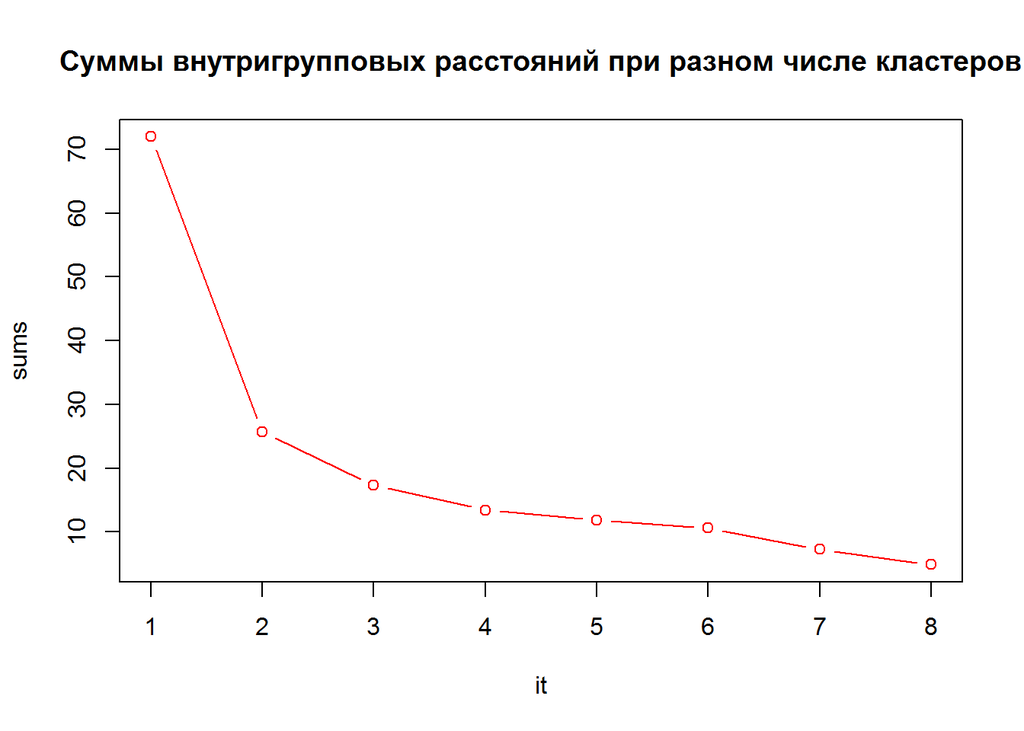

```r
it = 1:8
sums = sapply(it, function(k) kmeans(data[, 2:5], k)$tot.withinss)
plot(it, sums, type = "b", col = "red", main = "Суммы внутригрупповых расстояний при разном числе кластеров")
```

По принципу *метода каменистой осыпи* делаем вывод, что исходный набор данных естественно делится на 2 или 3 кластера. Напишем функцию, которая строит модель для заданного числа кластеров, проводит анализ этой модели и строит некоторые графики:

```r
# функция, проводящая некоторый анализ и строящая графики для заданного
# числа кластеров
getimage = function(k) {

    fit = kmeans(data[, 2:5], k)  #строится модель
    cat("Основная информация: \n")
    print(fit)

    # cat('Внутригрупповые суммы:',fit$withinss,'\n')#внутригрупповые суммы
    # cat('Общая сумма:', fit$betweenss,'\n')
    cat("Матрица расстояний:\n")
    print(dist(fit$centers))  #матрица расстояний
    cat("Центры:\n")
    print(fit$centers)


    # Добавляем кластер к фрейму данных
    library(dplyr)
    newdata = as_data_frame(data) %>% mutate(cluster = factor(fit$cluster))

    # агрегирование данных по группам
    means = newdata[, 2:6] %>% group_by(cluster) %>% summarise(meanCosts = mean(Costs),
        sdCosts = sd(Costs), meanDoctors = mean(Doctors), sdDoctors = sd(Doctors),
        meanGDP = mean(GDP), sdGDP = sd(GDP), meanDeaths = mean(Deaths), sdDeaths = sd(Deaths))
    print(means)


    means = means[, c(1, 2, 4, 6, 8)]  #берётся сабсет только из значений для средних

    lbs = c("cluster1", "cluster2", "cluster3", "cluster4", "cluster5")

    library(ggplot2)
    library(ggpubr)

    # здесь создаётся таблица со средними по каждой переменной и каждому классу
    # в том виде, в каком удобней рисовать
    tmpdata = data.frame(x = 1:4, means = as.numeric(means[1, 2:5]), cluster = rep(lbs[1],
        4))
    for (i in 2:k) {
        tmpdata = rbind(tmpdata, data.frame(x = 1:4, means = as.numeric(means[i,
            2:5]), cluster = rep(lbs[i], 4)))
    }
    tmpdata$cluster = factor(tmpdata$cluster)


    ppp = ggplot(tmpdata, aes(x = x, y = means, col = cluster)) + geom_line() +
        geom_point(size = 4)


    pl1 = ggplot(newdata, aes(x = Doctors, y = Deaths, col = cluster)) + geom_point(size = 3) +
        theme_bw()

    pl2 = ggplot(newdata, aes(x = GDP, y = Costs, col = cluster)) + geom_point(size = 3) +
        theme_bw()

    pl3 = ggplot(newdata, aes(x = GDP, y = Deaths, col = cluster)) + geom_point(size = 3) +
        theme_bw()
    pl4 = ggplot(newdata, aes(x = GDP, y = Doctors, col = cluster)) + geom_point(size = 3) +
        theme_bw()

    costs = ggplot(newdata, aes(x = cluster, y = Costs)) + geom_boxplot() +
        theme_bw()
    deaths = ggplot(newdata, aes(x = cluster, y = Deaths)) + geom_boxplot() +
        theme_bw()
    doctors = ggplot(newdata, aes(x = cluster, y = Doctors)) + geom_boxplot() +
        theme_bw()
    gdp = ggplot(newdata, aes(x = cluster, y = GDP)) + geom_boxplot() + theme_bw()

    p1 <- ggarrange(pl1, pl2, pl3, pl4, ncol = 2, nrow = 2)
    p2 <- ggarrange(costs, deaths, doctors, gdp, ncol = 2, nrow = 2)
    ggarrange(ppp, p1, p2, ncol = 1, nrow = 3, heights = c(1.3, 2, 3))
}
getimage2 = function(k) {
    fit = kmeans(data[, 2:5], k)  #строится модель

    # Добавляем кластер к фрейму данных
    library(dplyr)
    newdata = as_data_frame(data) %>% mutate(cluster = factor(fit$cluster))
    cat("Дисперсионный анализ для каждой переменной,", k, "кластеров \n")
    cat("Затраты: \n")
    print(summary(aov(Costs ~ cluster, newdata)))
    cat("Смерти: \n")
    print(summary(aov(Deaths ~ cluster, newdata)))
    cat("Врачи: \n")
    print(summary(aov(Doctors ~ cluster, newdata)))
    cat("ВВП: \n")
    print(summary(aov(GDP ~ cluster, newdata)))

    # рисуются кластеры через главные компоненты library(cluster)
    # print(clusplot(newdata, newdata$cluster, color=TRUE, shade=TRUE, labels=2,
    # lines=0))
    library(factoextra)
    print(fviz_cluster(fit, data[, -1], ellipse.type = "norm"))
}
```

Используем эту функцию для **двух** кластеров:

```
## Основная информация:
## K-means clustering with 2 clusters of sizes 10, 9
##
## Cluster means:
##      Doctors     Deaths        GDP      Costs
## 1 -0.3094347 -0.8535616  0.8736311  0.7776878
## 2  0.3438163  0.9484018 -0.9707013 -0.8640976
##
## Clustering vector:
##  1  2  3  4  5  6  7  8  9 10 11 12 13 14 15 16 17 18 19
##  2  1  1  2  2  2  2  1  2  1  1  2  1  1  1  1  2  1  2
##
## Within cluster sum of squares by cluster:
## [1] 16.671286  9.045834
##  (between_SS / total_SS =  64.3 %)
##
## Available components:
##
## [1] "cluster"      "centers"      "totss"        "withinss"
## [5] "tot.withinss" "betweenss"    "size"         "iter"
## [9] "ifault"
## Матрица расстояний:
##          1
## 2 3.125833
## Центры:
##      Doctors     Deaths        GDP      Costs
## 1 -0.3094347 -0.8535616  0.8736311  0.7776878
## 2  0.3438163  0.9484018 -0.9707013 -0.8640976
## # A tibble: 2 x 9
##   cluster meanCosts sdCosts meanDoctors sdDoctors meanGDP sdGDP meanDeaths
##   <fct>       <dbl>   <dbl>       <dbl>     <dbl>   <dbl> <dbl>      <dbl>
## 1 1           0.778   0.596      -0.309     1.12    0.874 0.426     -0.854
## 2 2          -0.864   0.504       0.344     0.766  -0.971 0.177      0.948
## # ... with 1 more variable: sdDeaths <dbl>
```

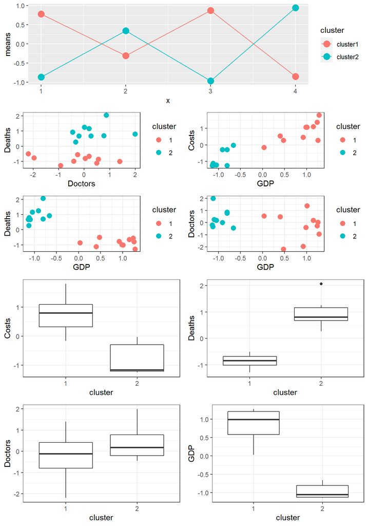

```r
getimage(2)
```

Видно, что исходные наблюдения хорошо разделяются на две группы. Если использовать **три** кластера, такое разделение будет уже сомнительным:

```
## Основная информация:
## K-means clustering with 3 clusters of sizes 9, 8, 2
##
## Cluster means:
##      Doctors     Deaths        GDP      Costs
## 1  0.3438163  0.9484018 -0.9707013 -0.8640976
## 2  0.1318025 -0.9074724  0.9173579  0.8810550
## 3 -2.0743833 -0.6379186  0.6987241  0.3642190
##
## Clustering vector:
##  1  2  3  4  5  6  7  8  9 10 11 12 13 14 15 16 17 18 19
##  1  2  2  1  1  1  1  3  1  2  2  1  2  3  2  2  1  2  1
##
## Within cluster sum of squares by cluster:
## [1] 9.0458341 8.0886580 0.1748924
##  (between_SS / total_SS =  76.0 %)
##
## Available components:
##
## [1] "cluster"      "centers"      "totss"        "withinss"
## [5] "tot.withinss" "betweenss"    "size"         "iter"
## [9] "ifault"
## Матрица расстояний:
##          1        2
## 2 3.177978
## 3 3.558067 2.292343
## Центры:
##      Doctors     Deaths        GDP      Costs
## 1  0.3438163  0.9484018 -0.9707013 -0.8640976
## 2  0.1318025 -0.9074724  0.9173579  0.8810550
## 3 -2.0743833 -0.6379186  0.6987241  0.3642190
## # A tibble: 3 x 9
##   cluster meanCosts sdCosts meanDoctors sdDoctors meanGDP sdGDP meanDeaths
##   <fct>       <dbl>   <dbl>       <dbl>     <dbl>   <dbl> <dbl>      <dbl>
## 1 1          -0.864   0.504       0.344     0.766  -0.971 0.177      0.948
## 2 2           0.881   0.627       0.132     0.704   0.917 0.457     -0.907
## 3 3           0.364   0.123      -2.07      0.158   0.699 0.315     -0.638
## # ... with 1 more variable: sdDeaths <dbl>
```

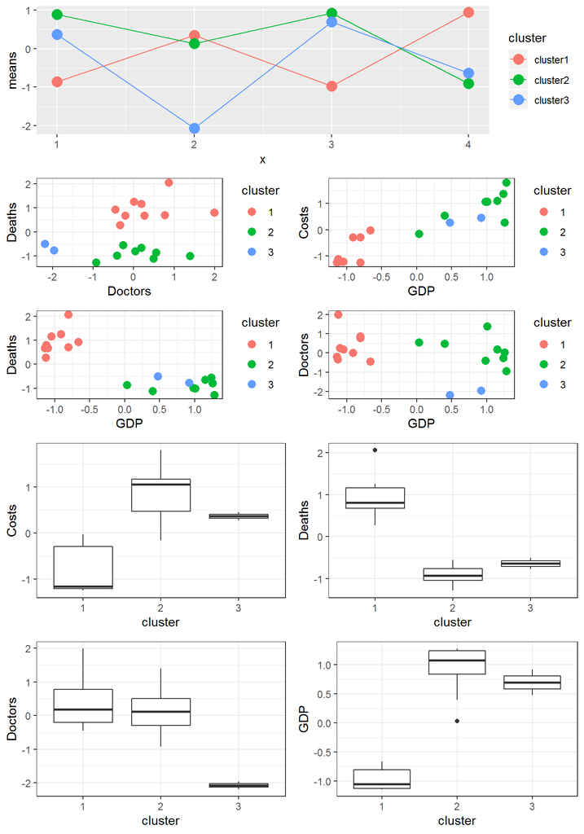

```r
getimage(3)
```

Теперь попробуем визуально оценить качество кластеризации через *главные компоненты* (дополнительно делается *дисперсионный анализ* по каждой переменной):

```
## Дисперсионный анализ для каждой переменной, 2 кластеров
## Затраты:
##             Df Sum Sq Mean Sq F value   Pr(>F)
## cluster      1 12.768  12.768   41.49 6.09e-06 ***
## Residuals   17  5.232   0.308
## ---
## Signif. codes:  0 '***' 0.001 '**' 0.01 '*' 0.05 '.' 0.1 ' ' 1
## Смерти:
##             Df Sum Sq Mean Sq F value   Pr(>F)
## cluster      1 15.381  15.381   99.83 1.57e-08 ***
## Residuals   17  2.619   0.154
## ---
## Signif. codes:  0 '***' 0.001 '**' 0.01 '*' 0.05 '.' 0.1 ' ' 1
## Врачи:
##             Df Sum Sq Mean Sq F value Pr(>F)
## cluster      1  2.021  2.0214   2.151  0.161
## Residuals   17 15.979  0.9399
## ВВП:
##             Df Sum Sq Mean Sq F value   Pr(>F)
## cluster      1 16.113  16.113   145.1 9.48e-10 ***
## Residuals   17  1.887   0.111
## ---
## Signif. codes:  0 '***' 0.001 '**' 0.01 '*' 0.05 '.' 0.1 ' ' 1
```

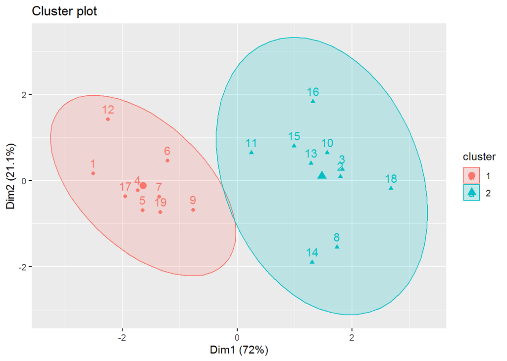

```
## Дисперсионный анализ для каждой переменной, 3 кластеров
## Затраты:
##             Df Sum Sq Mean Sq F value   Pr(>F)
## cluster      2 13.195   6.598   21.97 2.58e-05 ***
## Residuals   16  4.805   0.300
## ---
## Signif. codes:  0 '***' 0.001 '**' 0.01 '*' 0.05 '.' 0.1 ' ' 1
## Смерти:
##             Df Sum Sq Mean Sq F value  Pr(>F)
## cluster      2 15.497   7.749   49.53 1.4e-07 ***
## Residuals   16  2.503   0.156
## ---
## Signif. codes:  0 '***' 0.001 '**' 0.01 '*' 0.05 '.' 0.1 ' ' 1
## Врачи:
##             Df Sum Sq Mean Sq F value  Pr(>F)
## cluster      2  9.809   4.904    9.58 0.00184 **
## Residuals   16  8.191   0.512
## ---
## Signif. codes:  0 '***' 0.001 '**' 0.01 '*' 0.05 '.' 0.1 ' ' 1
## ВВП:
##             Df Sum Sq Mean Sq F value   Pr(>F)
## cluster      2 16.189   8.095   71.52 1.05e-08 ***
## Residuals   16  1.811   0.113
## ---
## Signif. codes:  0 '***' 0.001 '**' 0.01 '*' 0.05 '.' 0.1 ' ' 1
```

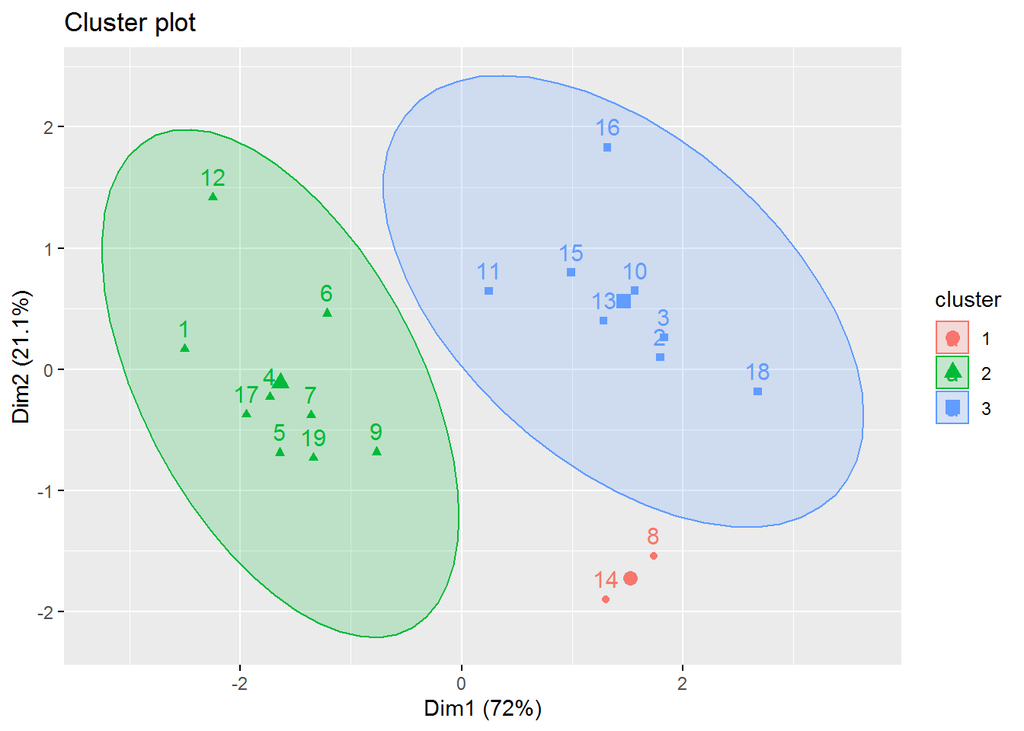

```
## Дисперсионный анализ для каждой переменной, 4 кластеров
## Затраты:
##             Df Sum Sq Mean Sq F value   Pr(>F)
## cluster      3 14.744   4.915   22.64 8.01e-06 ***
## Residuals   15  3.256   0.217
## ---
## Signif. codes:  0 '***' 0.001 '**' 0.01 '*' 0.05 '.' 0.1 ' ' 1
## Смерти:
##             Df Sum Sq Mean Sq F value   Pr(>F)
## cluster      3 16.105   5.368   42.49 1.44e-07 ***
## Residuals   15  1.895   0.126
## ---
## Signif. codes:  0 '***' 0.001 '**' 0.01 '*' 0.05 '.' 0.1 ' ' 1
## Врачи:
##             Df Sum Sq Mean Sq F value Pr(>F)
## cluster      3  5.073  1.6910   1.962  0.163
## Residuals   15 12.927  0.8618
## ВВП:
##             Df Sum Sq Mean Sq F value   Pr(>F)
## cluster      3 16.277   5.426   47.24 7.06e-08 ***
## Residuals   15  1.723   0.115
## ---
## Signif. codes:  0 '***' 0.001 '**' 0.01 '*' 0.05 '.' 0.1 ' ' 1
```

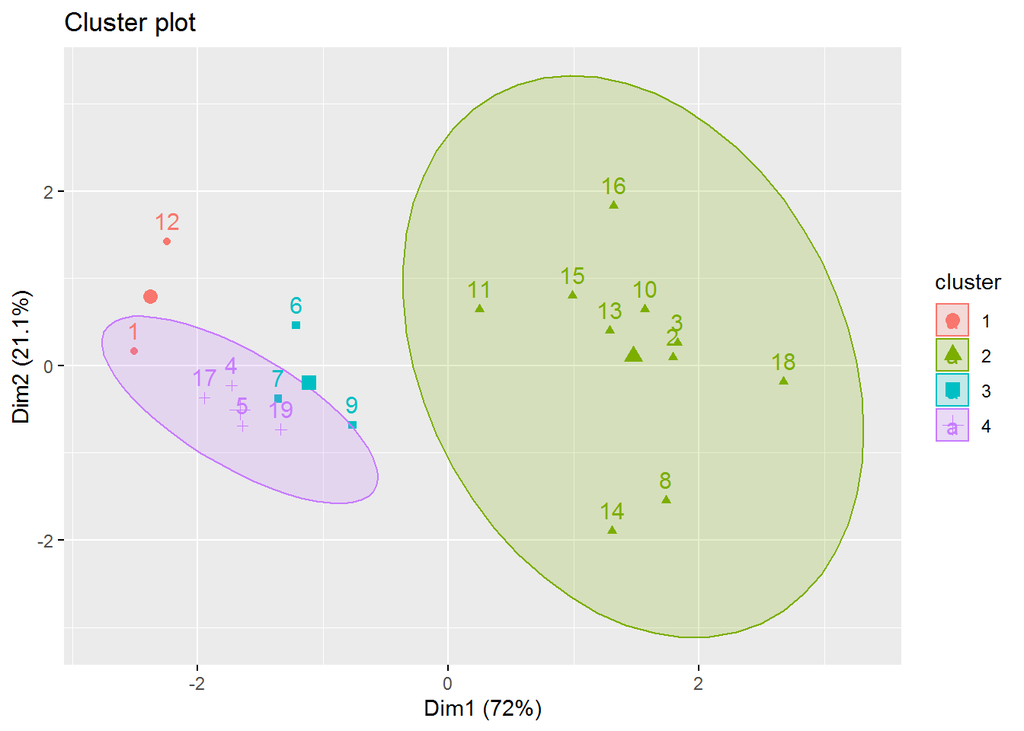

```
## Дисперсионный анализ для каждой переменной, 5 кластеров
## Затраты:
##             Df Sum Sq Mean Sq F value   Pr(>F)
## cluster      4 15.085   3.771   18.11 2.01e-05 ***
## Residuals   14  2.915   0.208
## ---
## Signif. codes:  0 '***' 0.001 '**' 0.01 '*' 0.05 '.' 0.1 ' ' 1
## Смерти:
##             Df Sum Sq Mean Sq F value   Pr(>F)
## cluster      4 16.114   4.029   29.91 1.01e-06 ***
## Residuals   14  1.886   0.135
## ---
## Signif. codes:  0 '***' 0.001 '**' 0.01 '*' 0.05 '.' 0.1 ' ' 1
## Врачи:
##             Df Sum Sq Mean Sq F value  Pr(>F)
## cluster      4 14.707   3.677   15.63 4.6e-05 ***
## Residuals   14  3.293   0.235
## ---
## Signif. codes:  0 '***' 0.001 '**' 0.01 '*' 0.05 '.' 0.1 ' ' 1
## ВВП:
##             Df Sum Sq Mean Sq F value  Pr(>F)
## cluster      4 16.666   4.166   43.71 9.2e-08 ***
## Residuals   14  1.334   0.095
## ---
## Signif. codes:  0 '***' 0.001 '**' 0.01 '*' 0.05 '.' 0.1 ' ' 1
```

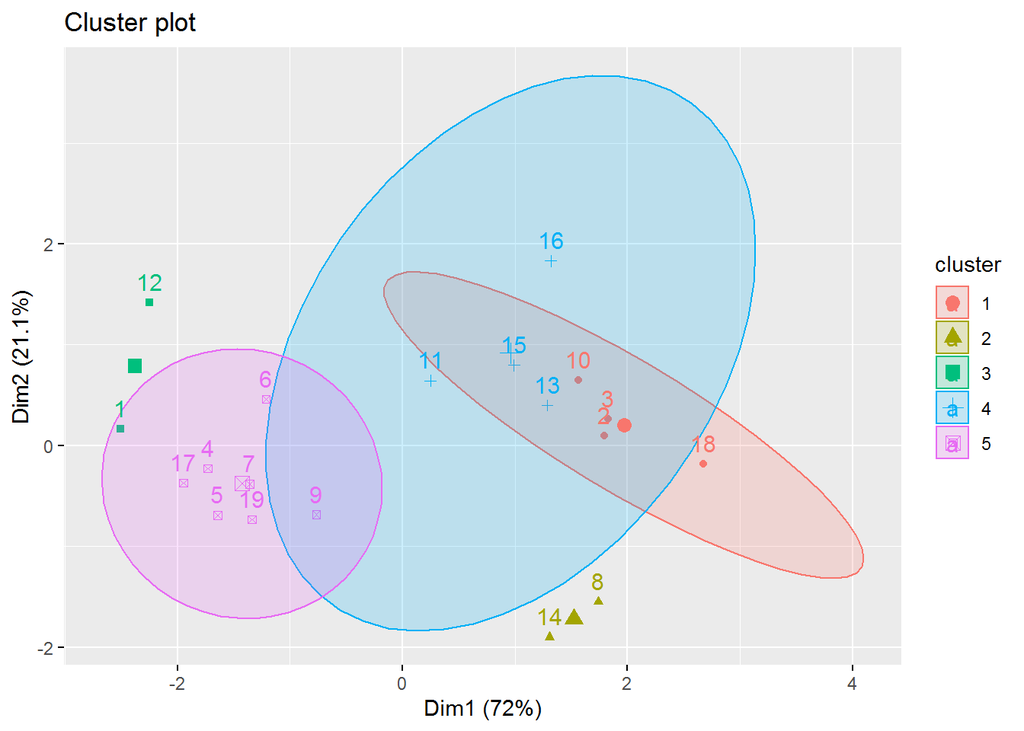

```r
for (i in 2:5) getimage2(i)
```

Ещё один способ оценивать качество разбиения на группы — **лица Чернова**. Идея состоит в том, чтобы для каждой группы найти какую-то характеристику каждой переменной (например, среднее), а затем на основе вектора таких характеристик постоить лица каждой группы: *чем лица более похожи, тем группы более близки*. Сделаем так **для двух кластеров**:

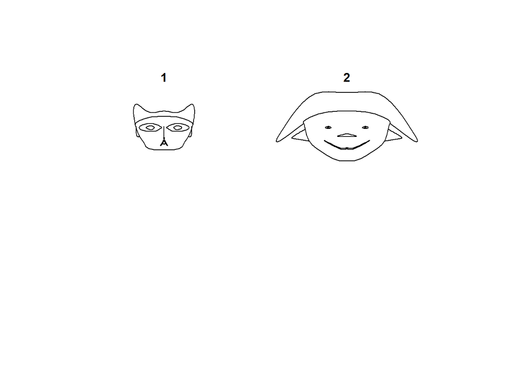

```r
# функция делает анализ dataset по методу k-means с k кластерами, затем
# добавляет результаты к датасету
getbykmeans = function(dataset, k) {
    fit = kmeans(dataset, k)  #строится модель
    # Добавляем кластер к фрейму данных
    library(dplyr)
    newdata = as_data_frame(dataset) %>% mutate(cluster = factor(fit$cluster))
}
# функция считает средние и рисует лица
getfaces = function(k) {
    # создаем матрицу средних
    means = getbykmeans(data[, 2:5], k) %>% group_by(cluster) %>% summarise_all(funs(mean))

    library(TeachingDemos)
    faces(means[, 2:5])  #рисуем лица
}
getfaces(2)
```

Видно, что лица сильно различаются. **Для трёх кластеров**

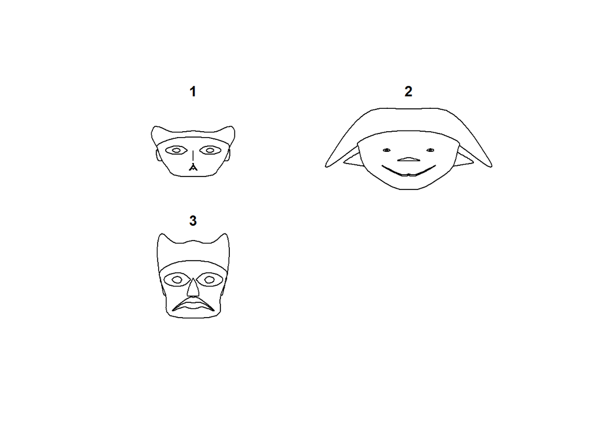

```r
getfaces(3)
```

два лица уже похожи. **Для четырёх кластеров** имеется две пары очень похожих лиц (то есть данные разбиваются на два кластера, а дальнейшее разбиение уже излишнее – происходит поиск различий там, где их нет):

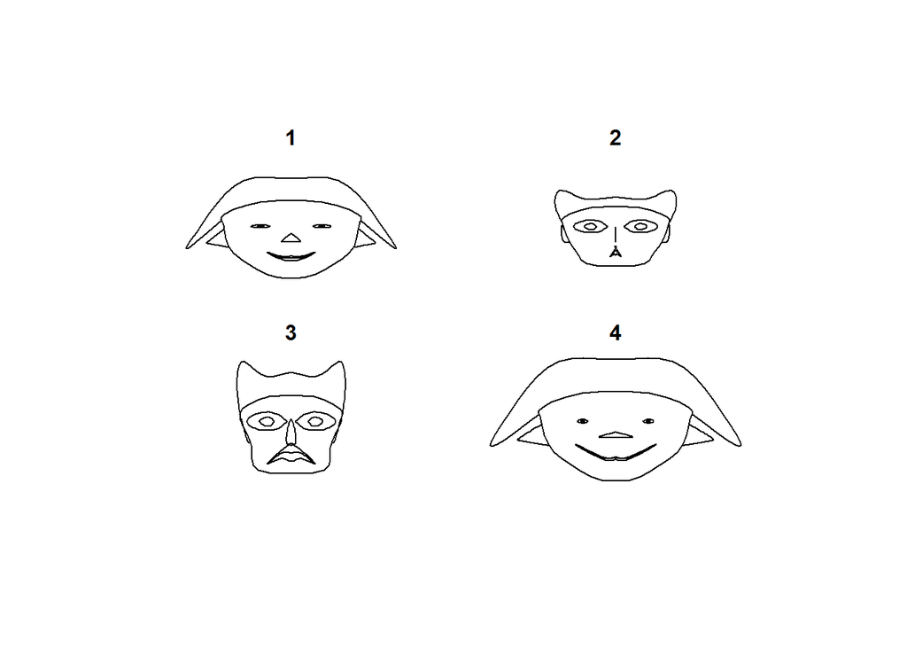

```r
getfaces(4)
```

Отсюда **вывод**: достаточно было использовать только два кластера.

### Задание 3

Загрузим **данные**:

```r
datacrude = data.frame(read_excel("Приложение 1.xlsx"))
data = datacrude[, -c(1)]
data = data[, -c(1, 2, 16, 17)]
data %>% tbl_df()
```

| Y3 | X4 | X5 | X6 | X7 | X8 | X9 | X10 | X11 | X12 | X13 | X14 | X15 |
| --- | --- | --- | --- | --- | --- | --- | --- | --- | --- | --- | --- | --- |
| 13.26 | 0.89 | 0.34 | 1.73 | 31.00 | 0.28 | 0.89 | 0.14 | 112216.00 | 166.19 | 9889.98 | 6.40 | 167.29 |
| 10.16 | 0.93 | 0.33 | 0.99 | 0.15 | 0.25 | 1.80 | 0.30 | 37631.94 | 186.10 | 22123.47 | 7.80 | 92.88 |
| 13.72 | 1.33 | 0.17 | 1.73 | 0.14 | 0.47 | 1.53 | 0.31 | 45178.00 | 220.45 | 10787.25 | 9.76 | 159.01 |
| 12.83 | 0.68 | 0.32 | 0.47 | 0.18 | 1.53 | 0.60 | 0.18 | 76688.00 | 169.30 | 10272.25 | 7.90 | 93.96 |
| 10.63 | 0.89 | 0.36 | 1.73 | 0.31 | 0.21 | 1.39 | 0.37 | 7361.00 | 39.93 | 55268.00 | 5.35 | 173.88 |
| 9.12 | 1.53 | 0.33 | 1.33 | 0.17 | 0.13 | 1.24 | 0.19 | 84496.00 | 40.41 | 45322.00 | 9.96 | 162.30 |
| 25.95 | 1.12 | 0.15 | 0.97 | 0.26 | 0.38 | 1.77 | 0.41 | 114132.00 | 102.96 | 12657.25 | 4.50 | 88.56 |
| 23.39 | 0.99 | 0.32 | 1.82 | 0.29 | 0.38 | 0.09 | 0.36 | 7801.00 | 37.02 | 57564.00 | 4.88 | 101.16 |
| 14.68 | 1.65 | 0.31 | 0.68 | 0.26 | 0.20 | 0.52 | 0.41 | 84504.00 | 45.94 | 118239.88 | 3.46 | 167.29 |
| 10.05 | 0.56 | 0.15 | 1.80 | 0.28 | 0.35 | 0.80 | 2.06 | 35852.00 | 40.07 | 64362.00 | 3.62 | 140.76 |

[output cut: 43 more lines]

**Визуализация корреляционной матрицы** заданного набора переменных:

```r
library(corrplot)
(matr = cor(data))
```

```
##              Y3          X4           X5          X6          X7
## Y3   1.00000000  0.07650448 -0.072024390 -0.19034971  0.11487125
## X4   0.07650448  1.00000000 -0.143222378 -0.05165605  0.02087309
## X5  -0.07202439 -0.14322238  1.000000000 -0.10105745  0.04470227
## X6  -0.19034971 -0.05165605 -0.101057451  1.00000000  0.12261894
## X7   0.11487125  0.02087309  0.044702272  0.12261894  1.00000000
## X8   0.41247593 -0.06787551 -0.041525168 -0.24074470 -0.03683463
## X9   0.03646200  0.10789499 -0.113522027  0.02500297 -0.05390234
## X10  0.08137700 -0.18976437  0.070132267 -0.04524674 -0.11608259
## X11  0.06540456 -0.07079232  0.033116213  0.22954802  0.19025176
## X12  0.01947580 -0.36101268  0.032584704 -0.00409325  0.09312382
## X13  0.05655101  0.35261229  0.017754637  0.08272441  0.05377388
## X14 -0.10504111 -0.01039568 -0.090105051 -0.17096373  0.03176305
## X15 -0.19945635  0.21542253  0.008607521  0.28241807  0.04977926
##              X8            X9         X10         X11         X12
## Y3   0.41247593  0.0364619968  0.08137700  0.06540456  0.01947580
## X4  -0.06787551  0.1078949930 -0.18976437 -0.07079232 -0.36101268
## X5  -0.04152517 -0.1135220265  0.07013227  0.03311621  0.03258470
## X6  -0.24074470  0.0250029745 -0.04524674  0.22954802 -0.00409325
## X7  -0.03683463 -0.0539023369 -0.11608259  0.19025176  0.09312382
## X8   1.00000000 -0.1007706318 -0.15649952 -0.01102561  0.14129715
## X9  -0.10077063  1.0000000000  0.30517775 -0.24507910 -0.09717025
## X10 -0.15649952  0.3051777477  1.00000000 -0.04511818 -0.14281619
## X11 -0.01102561 -0.2450790952 -0.04511818  1.00000000  0.31083103
## X12  0.14129715 -0.0971702535 -0.14281619  0.31083103  1.00000000
## X13 -0.09511029 -0.0677385171  0.05003536 -0.05178378 -0.36987532
## X14  0.20164538 -0.0005369078 -0.26948437  0.14258917  0.62254065
## X15 -0.13295559 -0.0159931107 -0.14937007 -0.08199636 -0.28801774
##             X13           X14          X15
## Y3   0.05655101 -0.1050411148 -0.199456352
## X4   0.35261229 -0.0103956837  0.215422531
## X5   0.01775464 -0.0901050514  0.008607521
## X6   0.08272441 -0.1709637327  0.282418070
## X7   0.05377388  0.0317630498  0.049779257
## X8  -0.09511029  0.2016453817 -0.132955585
## X9  -0.06773852 -0.0005369078 -0.015993111
## X10  0.05003536 -0.2694843746 -0.149370073
## X11 -0.05178378  0.1425891667 -0.081996358
## X12 -0.36987532  0.6225406492 -0.288017745
## X13  1.00000000 -0.2539722434  0.073307149
## X14 -0.25397224  1.0000000000 -0.254812455
## X15  0.07330715 -0.2548124551  1.000000000
```

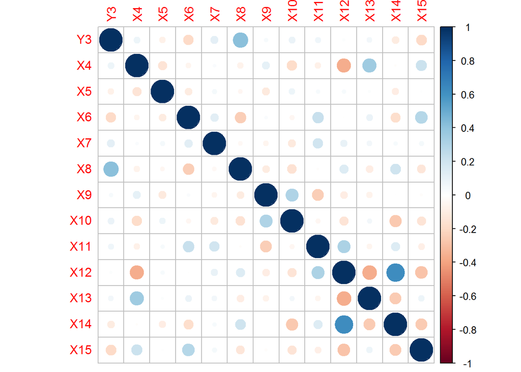

```r
corrplot(matr)
```

В наборе данных в целом нет значительных корреляций, поэтому сжать его до трёх-четырёх главных компонент без сильной потери информации не получится.

**Результаты аналаза методом главных компонент без вращения**:

```r
library(psych)
principal(data[, -1], nfactors = 8, rotate = "none")  #Создание модели
```

```
## Principal Components Analysis
## Call: principal(r = data[, -1], nfactors = 8, rotate = "none")
## Standardized loadings (pattern matrix) based upon correlation matrix
##       PC1   PC2   PC3   PC4   PC5   PC6   PC7   PC8   h2     u2 com
## X4  -0.45  0.21 -0.60  0.18  0.31  0.12 -0.23  0.18 0.84 0.1588 3.7
## X5   0.03 -0.03  0.29 -0.66 -0.02  0.52 -0.27  0.30 0.96 0.0374 3.3
## X6  -0.20  0.55  0.45  0.37 -0.15 -0.19  0.03  0.17 0.77 0.2290 3.8
## X7   0.08  0.49  0.12  0.00  0.38  0.50  0.54 -0.24 0.99 0.0061 4.4
## X8   0.37 -0.14 -0.46 -0.23 -0.12 -0.16  0.56  0.46 0.99 0.0132 4.7
## X9  -0.21 -0.47  0.10  0.62  0.16  0.34  0.08  0.30 0.90 0.0986 3.6
## X10 -0.23 -0.54  0.56  0.01  0.30 -0.11  0.10  0.17 0.80 0.1992 3.3
## X11  0.36  0.53  0.32 -0.04  0.31 -0.28 -0.07  0.32 0.80 0.2047 4.8
## X12  0.85  0.10  0.14  0.15  0.04  0.07 -0.14  0.05 0.80 0.1977 1.2
## X13 -0.54  0.19 -0.19 -0.24  0.51 -0.19 -0.06  0.08 0.73 0.2682 3.3
## X14  0.73  0.03 -0.32  0.28  0.15  0.16 -0.25  0.08 0.84 0.1649 2.3
## X15 -0.47  0.42 -0.04  0.12 -0.53  0.24  0.01  0.23 0.81 0.1936 3.9
##
##                        PC1  PC2  PC3  PC4  PC5  PC6  PC7  PC8
## SS loadings           2.39 1.63 1.45 1.23 1.05 0.93 0.84 0.71
## Proportion Var        0.20 0.14 0.12 0.10 0.09 0.08 0.07 0.06
## Cumulative Var        0.20 0.34 0.46 0.56 0.65 0.72 0.79 0.85
## Proportion Explained  0.23 0.16 0.14 0.12 0.10 0.09 0.08 0.07
## Cumulative Proportion 0.23 0.39 0.54 0.66 0.76 0.85 0.93 1.00
##
## Mean item complexity =  3.5
## Test of the hypothesis that 8 components are sufficient.
##
## The root mean square of the residuals (RMSR) is  0.06
##  with the empirical chi square  27.65  with prob <  NA
##
## Fit based upon off diagonal values = 0.87
```

Здесь *сперва выведена матрица корреляций*, затем **SS loadings** — это собственные значения каждой компоненты, **Proportion Var** — доля дисперсий, объясняемых каждой компонентой, **Cumulative Var** — кумулятивная доля (первая компонента объясняет 20%, первые две вместе — 34%, первые три — 46% и т. д.), дальше то же самое, только в пропорции. *По принципу Кайзера* следует выделить только 5 компонент, хотя, судя по объяснённым дисперсиям, и восьми может быть недостаточно.

Построим **диаграмму каменистой осыпи**:

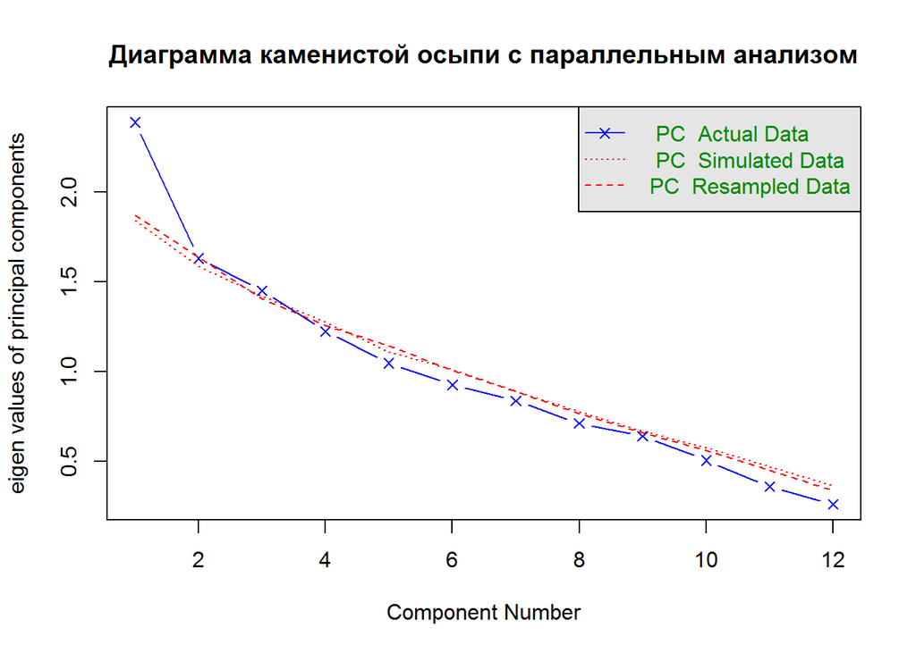

```r
fa.parallel(data[, -1], fa = "pc", show.legend = T, main = "Диаграмма каменистой осыпи с параллельным анализом")
```

Здесь, как и ожидалось, не наблюдается резкого убывания собственных значений, поэтому нельзя сказать, сколько конкретно главных компонент следовало бы выделить. Возмём 6 факторов и **проведём анализ с вращением осей**:

```r
# варимакс с нормализацией
(vm = principal(apply(data[, -1], 2, scale), nfactors = 6, rotate = "varimax"))
```

```
## Principal Components Analysis
## Call: principal(r = apply(data[, -1], 2, scale), nfactors = 6, rotate = "varimax")
## Standardized loadings (pattern matrix) based upon correlation matrix
##       RC1   RC5   RC3   RC2   RC4   RC6   h2   u2 com
## X4   0.64 -0.02 -0.27 -0.28  0.32  0.30 0.75 0.25 2.9
## X5  -0.04 -0.06  0.05 -0.02 -0.87  0.17 0.80 0.20 1.1
## X6  -0.06  0.75  0.06  0.33  0.23  0.08 0.74 0.26 1.6
## X7   0.05  0.13 -0.06  0.16 -0.18  0.75 0.65 0.35 1.3
## X8  -0.10 -0.49 -0.39  0.02  0.03 -0.24 0.46 0.54 2.5
## X9  -0.10  0.06  0.51 -0.61  0.32  0.24 0.81 0.19 2.9
## X10  0.05 -0.03  0.85 -0.04 -0.10 -0.16 0.76 0.24 1.1
## X11 -0.10  0.07  0.02  0.78  0.08  0.25 0.69 0.31 1.3
## X12 -0.71 -0.27 -0.08  0.33  0.10  0.29 0.78 0.22 2.2
## X13  0.82 -0.03  0.07  0.16  0.01  0.09 0.72 0.28 1.1
## X14 -0.48 -0.46 -0.27  0.04  0.32  0.39 0.77 0.23 4.4
## X15  0.13  0.71 -0.39 -0.27 -0.10 -0.01 0.75 0.25 2.0
##
##                        RC1  RC5  RC3  RC2  RC4  RC6
## SS loadings           1.88 1.63 1.45 1.41 1.18 1.14
## Proportion Var        0.16 0.14 0.12 0.12 0.10 0.09
## Cumulative Var        0.16 0.29 0.41 0.53 0.63 0.72
## Proportion Explained  0.22 0.19 0.17 0.16 0.14 0.13
## Cumulative Proportion 0.22 0.40 0.57 0.73 0.87 1.00
##
## Mean item complexity =  2
## Test of the hypothesis that 6 components are sufficient.
##
## The root mean square of the residuals (RMSR) is  0.09
##  with the empirical chi square  56.3  with prob <  6.9e-09
##
## Fit based upon off diagonal values = 0.74
```

По результатам анализа видно, что *первая компонента сильно коррелирует с переменной Х13 (среднегодовой фонд заработной платы), пятая — с Х6 (удельный вес покупных изделий) и Х15 (оборачиваемость нормированных оборотных средств), третья — с Х10 (фондоотдача) и Х9 (удельный вес потерь от брака), вторая — с Х11 (среднегодовая численность ППП), четвёртая — с Х5 (удельный вес рабочих в составе ППП), шестая — с Х7 (коэффициент сменности оборудования)*.

Также можно увидеть **матрицу весовых коэффициентов**:

```r
round(unclass(vm$weights), 2)  #делается округление до второго знака, чтобы не занимала много места
```

```
##       RC1   RC5   RC3   RC2   RC4   RC6
## X4   0.37 -0.11 -0.16 -0.16  0.24  0.30
## X5  -0.04 -0.05  0.00 -0.11 -0.76  0.23
## X6  -0.10  0.50  0.05  0.24  0.22 -0.01
## X7   0.06  0.05  0.01  0.00 -0.20  0.69
## X8   0.01 -0.28 -0.27  0.02  0.01 -0.24
## X9  -0.14  0.05  0.34 -0.47  0.23  0.32
## X10  0.04 -0.07  0.59  0.06 -0.03 -0.07
## X11  0.06  0.03  0.10  0.57  0.11  0.11
## X12 -0.32 -0.07  0.00  0.12  0.06  0.19
## X13  0.54 -0.17  0.09  0.25  0.05  0.10
## X14 -0.18 -0.22 -0.13 -0.08  0.22  0.31
## X15 -0.10  0.48 -0.34 -0.26 -0.11 -0.02
```

а *корреляционная матрица для главных компонент показывает их ортогональность*:

```r
cor(vm$scores)
```

```
##               RC1           RC5           RC3           RC2           RC4
## RC1  1.000000e+00 -8.012483e-16 -2.760045e-16  4.618482e-16 -1.510586e-17
## RC5 -8.012483e-16  1.000000e+00  2.955139e-16 -4.884503e-16  9.632302e-16
## RC3 -2.760045e-16  2.955139e-16  1.000000e+00  3.283986e-17 -2.461076e-16
## RC2  4.618482e-16 -4.884503e-16  3.283986e-17  1.000000e+00  1.488276e-16
## RC4 -1.510586e-17  9.632302e-16 -2.461076e-16  1.488276e-16  1.000000e+00
## RC6 -1.196198e-16  6.003697e-16 -2.182999e-16  1.132043e-16 -1.495914e-15
##               RC6
## RC1 -1.196198e-16
## RC5  6.003697e-16
## RC3 -2.182999e-16
## RC2  1.132043e-16
## RC4 -1.495914e-15
## RC6  1.000000e+00
```

### Задание 4

Загрузим **данные**:

```r
data = data.frame(read_excel("Приложение 2.xlsx"))
data$CLASS = factor(data$CLASS)
data %>% tbl_df()
```

| X1 | X2 | X3 | X4 | X5 | X6 | X7 | CLASS |
| --- | --- | --- | --- | --- | --- | --- | --- |
| 2174.0 | 9658 | 466.0 | 386.0 | 35.0 | 36.4 | 1756.0 | 1 |
| 274.0 | 10477 | 2321.0 | 767.0 | 56.0 | 35.6 | 7884.0 | 1 |
| -146.0 | 6567 | 713.0 | 581.0 | 74.0 | 13.8 | 1501.0 | 1 |
| -338.0 | 10282 | 499.0 | 764.0 | 51.0 | 30.2 | 1466.0 | 1 |
| -716.0 | 9316 | 677.0 | 533.0 | 109.0 | 20.5 | 1486.0 | 1 |
| 892.8 | 6425 | 944.0 | 1390.0 | 78.0 | 13.2 | 1936.0 | 1 |
| 191.0 | 5367 | 786.0 | 819.0 | 104.0 | 13.7 | 2011.0 | 1 |
| 0.0 | 6342 | 486.0 | 261.0 | 52.0 | 24.1 | 1841.0 | 1 |
| -107.0 | 5868 | 531.0 | 450.0 | 63.0 | 22.3 | 1608.0 | 1 |
| -903.0 | 6330 | 636.0 | 401.0 | 69.0 | 17.6 | 1768.0 | 1 |

[output cut: 55 more lines]

**Визуализация**:

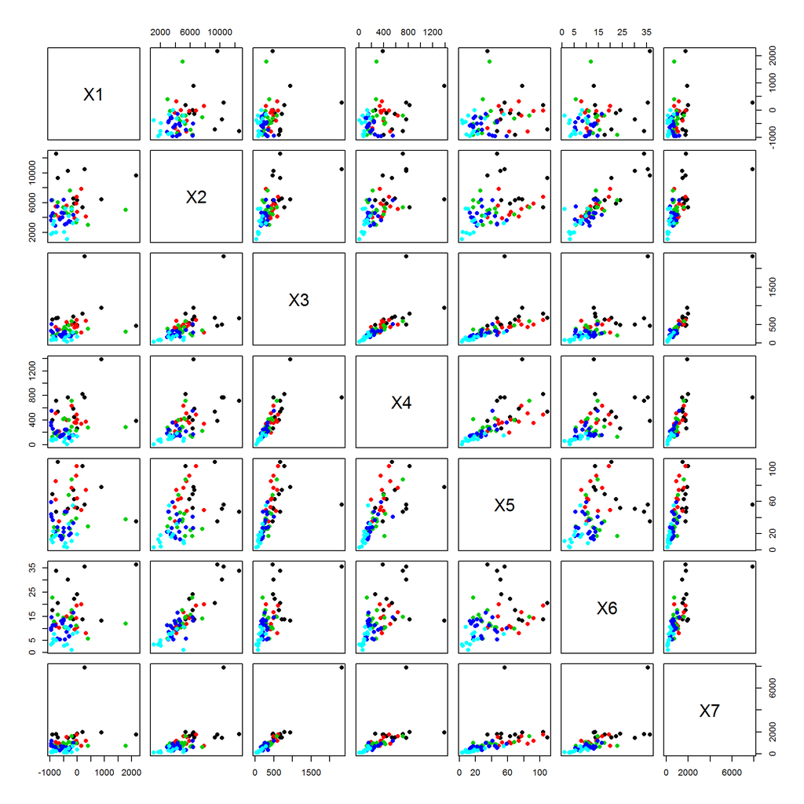

```r
pairs(data[, 1:7], col = data$CLASS, pch = 16)
```

Напишем несколько вспомогательных функций:

```r
library(MASS)
# лица Чернова
showfaces = function() {
    newdata = as_data_frame(data) %>% group_by(CLASS) %>% summarise_all(funs(mean))
    print(faces(newdata[, 2:8]))  #рисуем лица
}
# визуализация кластеров через главные компоненты
showimage = function() {
    library(factoextra)
    print(fviz_cluster(list(data = data[, 1:7], cluster = data[, 8]), ellipse.type = "norm"))
}

# матрицы, обратные матрицам ковариации для каждого класса
covinv = function(df) {
    res = list()
    for (i in 1:length(levels(df$CLASS))) res[[i]] = tryCatch({
        df[df$CLASS == i, 1:7] %>% as.matrix() %>% cov() %>% solve
    }, error = function(r) NA)
    # res[[i]]=df[df$CLASS==i,1:7] %>% as.matrix() %>% cov() %>% solve
    res
}

# расстояния Махаланобиса от элемента до каждого из классов
distance = function(means, covs, elem) {
    res = c()
    for (i in 1:nrow(means)) {
        vec = (means[i, ] - elem)
        res[i] = (vec %*% covs[[i]]) %*% vec
    }

    return(sqrt(res))
}

# поиск номера элемента в датафрейме
find.number = function(df, elem) {
    sm = 0
    i = 0
    len = length(elem)
    while (sm != len) {
        i = i + 1
        v = ifelse(df[i, ] == elem, T, F)
        sm = sum(v)
    }
    return(i)
}
```

Лица Чернова показывают, что в двух случаях между парами групп сильной разницы нет:

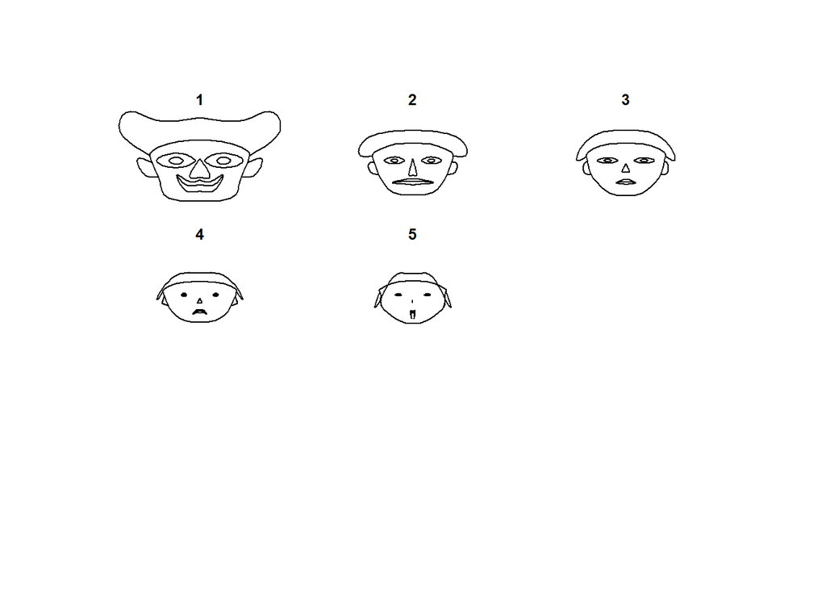

```r
showfaces()
```

Проведём обучение через *линейный дискриминантный анализ*:

```r
ldadat <- lda(CLASS ~ ., data, method = "moment")
```

**Результаты обучения**:

```r
# Функция вывода результатов классификации
Out_CTab <- function(model, group) {
    cat("Таблица неточностей \"Факт/Прогноз\" по обучающей выборке: \n")
    classified <- predict(model)$class
    t1 <- table(group, classified)
    print(t1)
    # Точность классификации и расстояние Махалонобиса
    Err_S <- mean(group != classified)
    mahDist <- dist(model$means %*% model$scaling)
    cat("Точность классификации:", 1 - Err_S[1], "\n")
    cat("Расстояния Махалонобиса:\n")
    print(mahDist)

    # Таблица 'Факт/Прогноз' и ошибка при скользящем контроле
    t2 <- table(group, LDA.cv <- update(model, CV = T)$class)
    Err_CV <- mean(group != LDA.cv)
    cat("Ошибка при скользящем контроле:", Err_CV[1], "\n")
    Err_S.MahD <- c(Err_S, mahDist)
    Err_CV.N <- c(Err_CV, length(group))
    cbind(t1, Err_S.MahD, t2, Err_CV.N)

    cat("Результаты многомерного дисперсионного анализа: \n")
    ldam <- manova(as.matrix(data[, 1:7]) ~ data$CLASS)
    print(summary(ldam, test = "Wilks"))
}
Out_CTab(ldadat, data$CLASS)
```

```
## Таблица неточностей "Факт/Прогноз" по обучающей выборке:
##      classified
## group  1  2  3  4  5
##     1  9  2  0  0  0
##     2  0  8  2  1  0
##     3  0  2  7  4  0
##     4  0  0  2 15  1
##     5  0  0  0  3  9
## Точность классификации: 0.7384615
## Расстояния Махалонобиса:
##          1        2        3        4
## 2 3.016556
## 3 3.680769 1.726019
## 4 4.766641 2.584622 1.213160
## 5 6.461644 4.081787 2.854497 1.855913
## Ошибка при скользящем контроле: 0.4615385
## Результаты многомерного дисперсионного анализа:
##            Df   Wilks approx F num Df den Df    Pr(>F)
## data$CLASS  4 0.12674   5.4173     28 196.12 2.994e-13 ***
## Residuals  60
## ---
## Signif. codes:  0 '***' 0.001 '**' 0.01 '*' 0.05 '.' 0.1 ' ' 1
```

*Точность классификации* достаточно низкая (74%), вдобавок *лямбда Уилкса* (**0.126**) сильно отличается от нуля. Откорректируем классификацию, чтобы добиться стопроцентной точности:

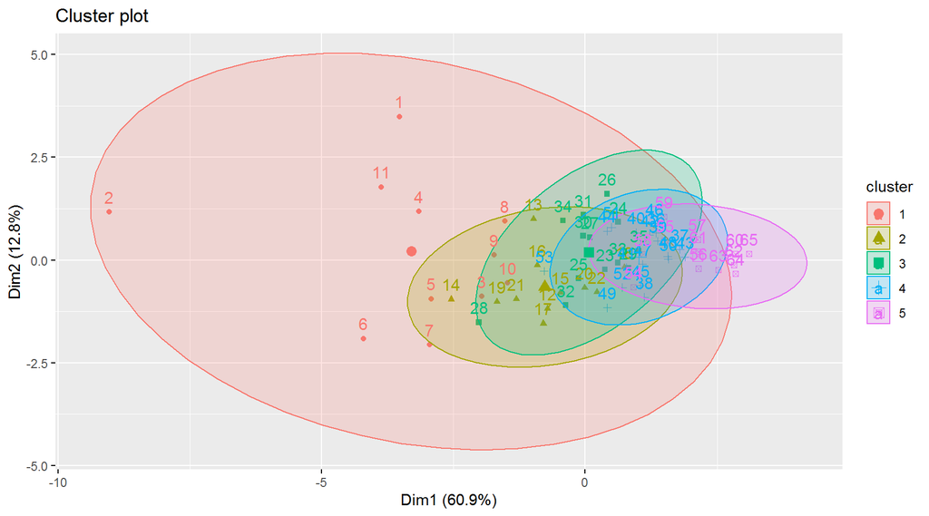

```
## Точность классификации: 0.7384615
## Неправильно отнесённый элемент с максимальным расстоянием ( 3.93429 )
##      X1   X2  X3  X4 X5   X6   X7 CLASS
## 53 -934 6322 510 548 41 14.7 1187     4
## Заменяется на
##      X1   X2  X3  X4 X5   X6   X7 CLASS
## 53 -934 6322 510 548 41 14.7 1187     3
```

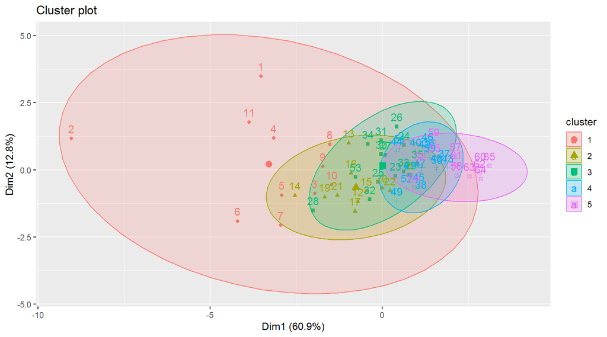

```
## Точность классификации: 0.7846154
## Неправильно отнесённый элемент с максимальным расстоянием ( 3.016765 )
##        X1   X2  X3  X4 X5  X6  X7 CLASS
## 54 -161.6 3196 288 149 55 7.6 684     5
## Заменяется на
##        X1   X2  X3  X4 X5  X6  X7 CLASS
## 54 -161.6 3196 288 149 55 7.6 684     4
```

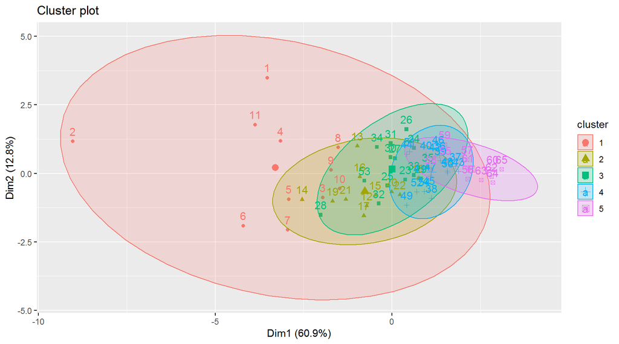

```
## Точность классификации: 0.7846154
## Неправильно отнесённый элемент с максимальным расстоянием ( 2.970361 )
##      X1   X2  X3 X4 X5  X6  X7 CLASS
## 56 -879 3058 169 86 23 5.6 307     5
## Заменяется на
##      X1   X2  X3 X4 X5  X6  X7 CLASS
## 56 -879 3058 169 86 23 5.6 307     4
```

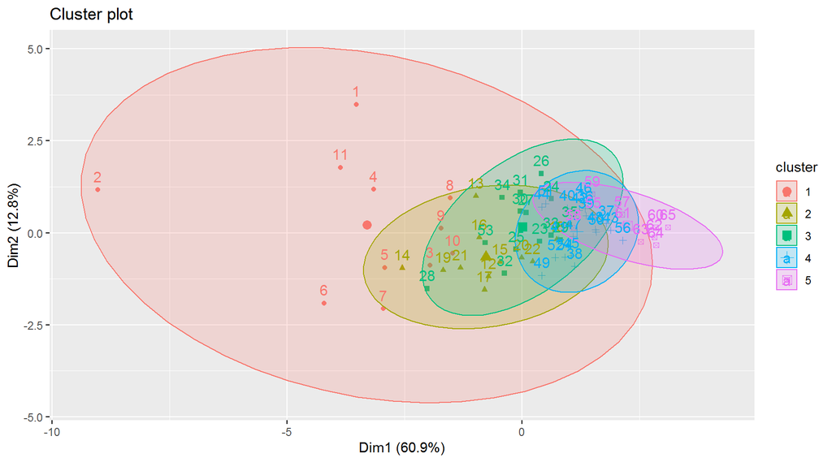

```
## Точность классификации: 0.8
## Неправильно отнесённый элемент с максимальным расстоянием ( 2.904711 )
##      X1   X2  X3  X4 X5   X6     X7 CLASS
## 28 -205 5357 583 716 87 14.8 1606.6     3
## Заменяется на
##      X1   X2  X3  X4 X5   X6     X7 CLASS
## 28 -205 5357 583 716 87 14.8 1606.6     2
```

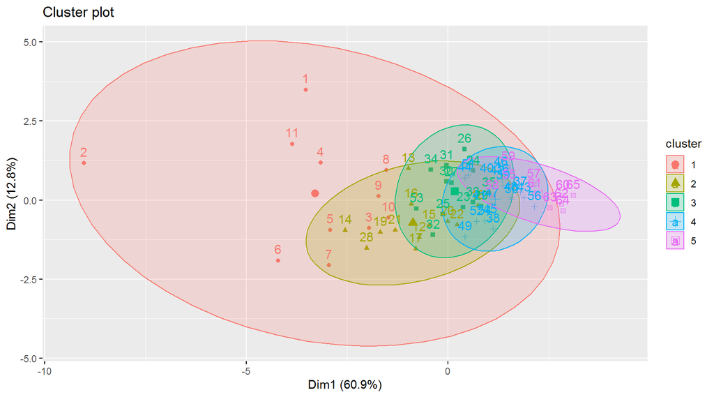

```
## Точность классификации: 0.8153846
## Неправильно отнесённый элемент с максимальным расстоянием ( 3.172017 )
##      X1   X2  X3  X4 X5   X6  X7 CLASS
## 51 -500 6368 288 169 27 13.3 601     4
## Заменяется на
##      X1   X2  X3  X4 X5   X6  X7 CLASS
## 51 -500 6368 288 169 27 13.3 601     3
```

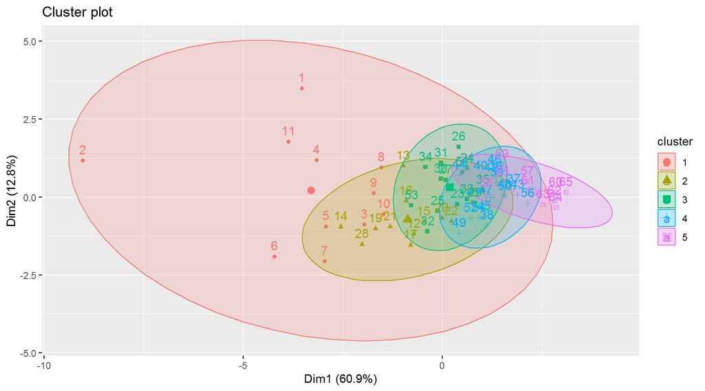

```
## Точность классификации: 0.8153846
## Неправильно отнесённый элемент с максимальным расстоянием ( 3.208787 )
##        X1   X2  X3  X4 X5  X6  X7 CLASS
## 47 -728.3 5448 348 215 28 5.7 367     4
## Заменяется на
##        X1   X2  X3  X4 X5  X6  X7 CLASS
## 47 -728.3 5448 348 215 28 5.7 367     3
```

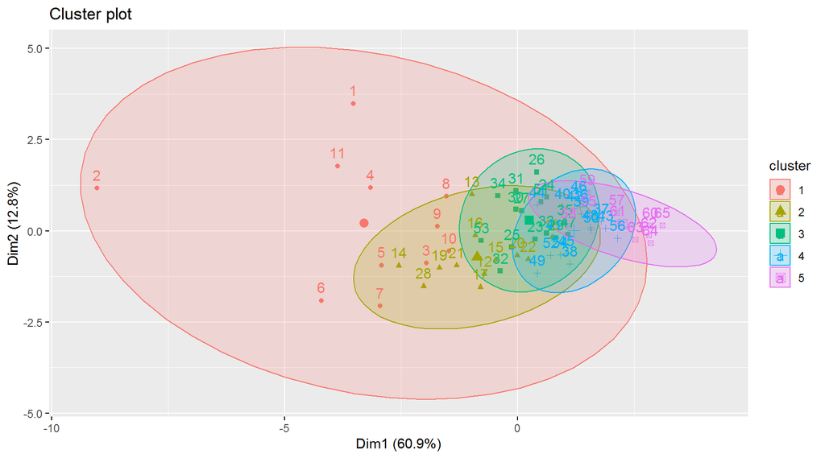

```
## Точность классификации: 0.8153846
## Неправильно отнесённый элемент с максимальным расстоянием ( 2.955268 )
##      X1   X2  X3  X4 X5   X6   X7 CLASS
## 16 -380 5564 565 400 48 14.9 1517     2
## Заменяется на
##      X1   X2  X3  X4 X5   X6   X7 CLASS
## 16 -380 5564 565 400 48 14.9 1517     3
```

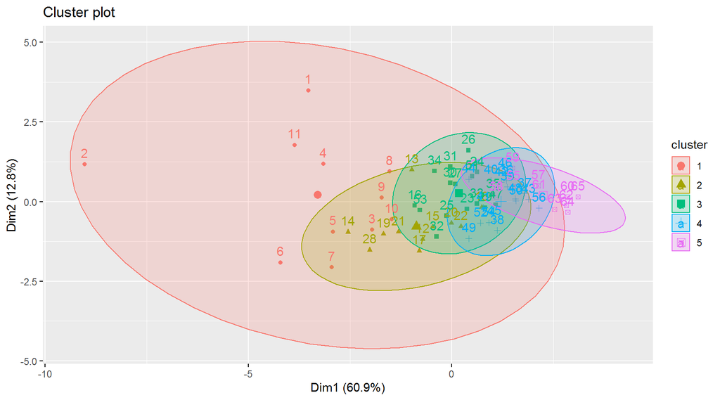

```
## Точность классификации: 0.8461538
## Неправильно отнесённый элемент с максимальным расстоянием ( 2.838619 )
##      X1   X2  X3  X4 X5  X6   X7 CLASS
## 32 -314 4394 471 396 68 9.9 1065     3
## Заменяется на
##      X1   X2  X3  X4 X5  X6   X7 CLASS
## 32 -314 4394 471 396 68 9.9 1065     2
```

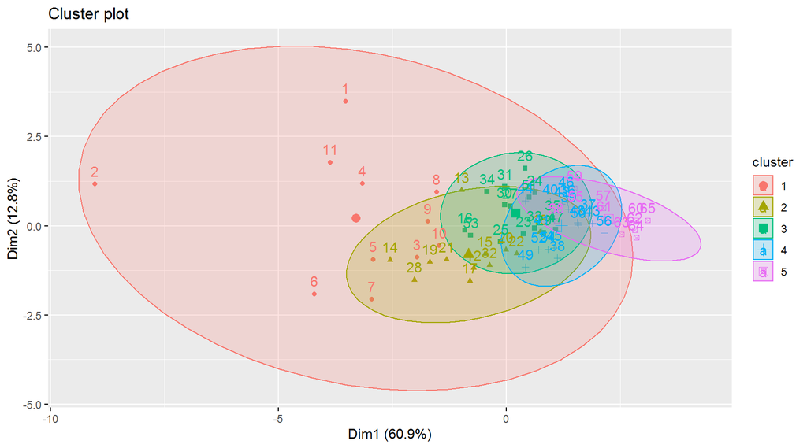

```
## Точность классификации: 0.8461538
## Неправильно отнесённый элемент с максимальным расстоянием ( 2.488618 )
##        X1   X2  X3  X4 X5   X6  X7 CLASS
## 18 -666.8 3988 364 213 35 10.3 943     2
## Заменяется на
##        X1   X2  X3  X4 X5   X6  X7 CLASS
## 18 -666.8 3988 364 213 35 10.3 943     4
```

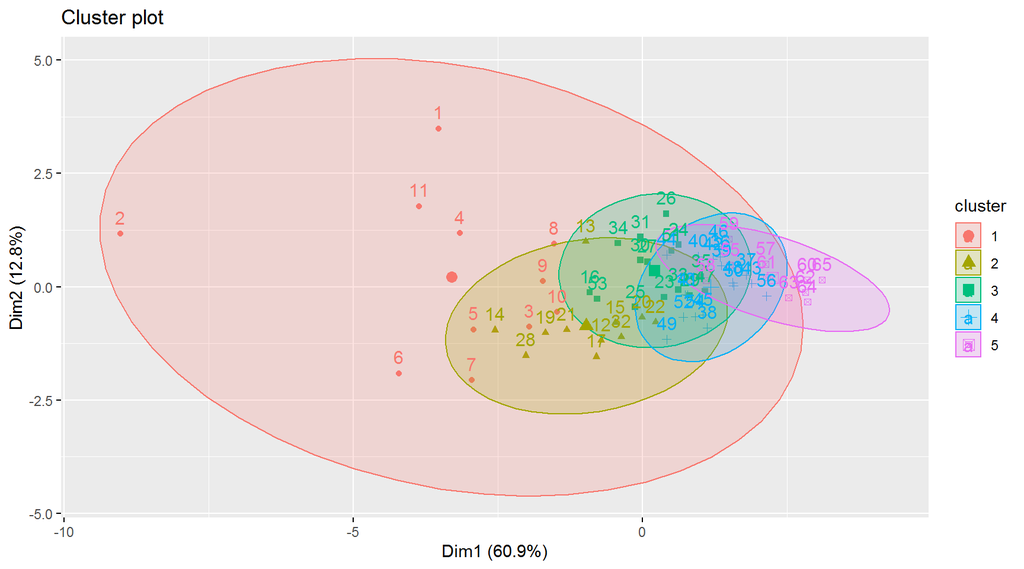

```
## Точность классификации: 0.8615385
## Неправильно отнесённый элемент с максимальным расстоянием ( 2.434652 )
##        X1   X2  X3  X4 X5  X6  X7 CLASS
## 58 -310.7 4166 207 183 32 9.8 487     5
## Заменяется на
##        X1   X2  X3  X4 X5  X6  X7 CLASS
## 58 -310.7 4166 207 183 32 9.8 487     4
```

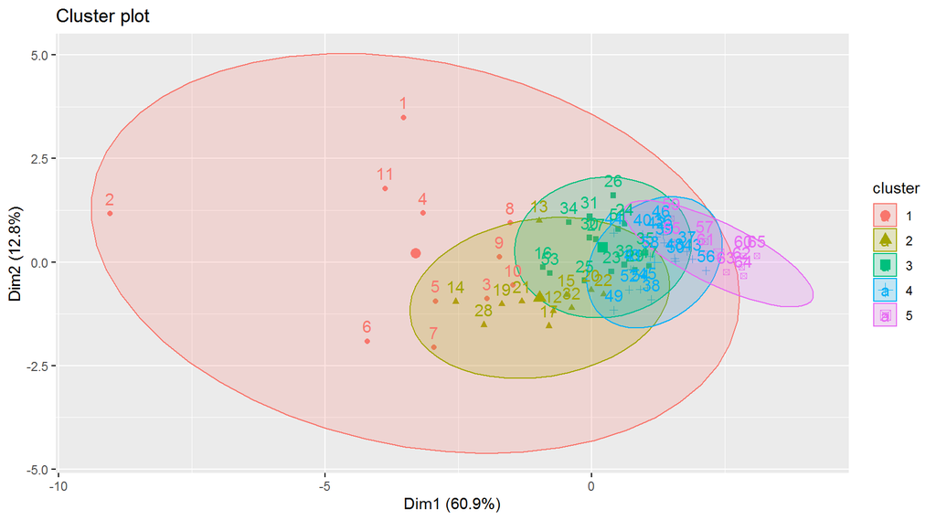

```
## Точность классификации: 0.8769231
## Неправильно отнесённый элемент с максимальным расстоянием ( 2.629277 )
##    X1   X2  X3  X4 X5  X6  X7 CLASS
## 55 -4 3666 168 131 19 8.3 382     5
## Заменяется на
##    X1   X2  X3  X4 X5  X6  X7 CLASS
## 55 -4 3666 168 131 19 8.3 382     4
```

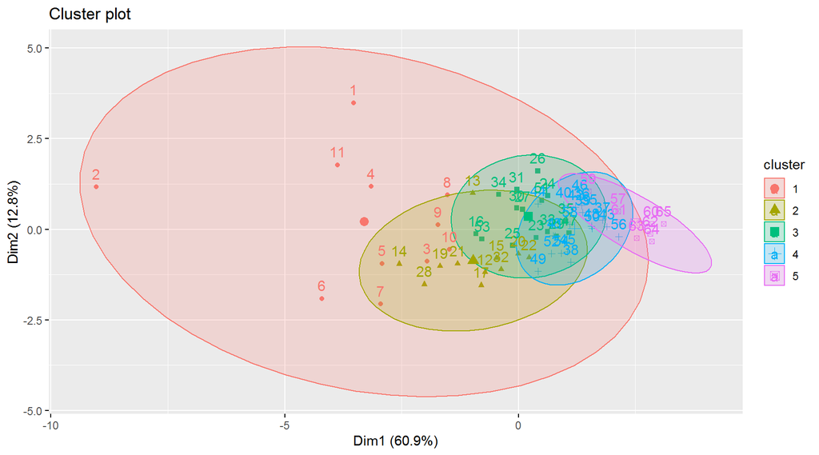

```
## Точность классификации: 0.8769231
## Неправильно отнесённый элемент с максимальным расстоянием ( 2.474874 )
##      X1   X2  X3 X4 X5   X6  X7 CLASS
## 59 -437 5168 151 96  8 10.7 359     5
## Заменяется на
##      X1   X2  X3 X4 X5   X6  X7 CLASS
## 59 -437 5168 151 96  8 10.7 359     4
```

[11 more figures not shown]

```
## Точность классификации: 1
```

```r
acc = 0  #точность
repeat {
    showimage()

    ldadat <- lda(CLASS ~ ., data, method = "moment")
    means = ldadat$means
    cov.mat = covinv(data)

    # для всех неправильно найденных найти расстояния до кластеров, отнесённых
    # экспертами
    prclass = predict(ldadat, data[, 1:7])$class
    st = data[data$CLASS != prclass, ]
    acc = 1 - nrow(st)/nrow(data)
    cat("Точность классификации:", acc, "\n")
    if (near(acc, 1))
        break

    if (nrow(st) == 1) {
        number.of.max.distance = 1
    } else {
        distances = c()
        for (i in 1:nrow(st)) {
            cls = as.numeric(st[i, 8])
            vec = (means[cls, ] - as.numeric(st[i, 1:7]))
            if (is.na(cov.mat[[cls]])) {
                distances[i] = NA
            } else {
                distances[i] = (vec %*% cov.mat[[cls]]) %*% vec
            }
        }
        distances = sqrt(distances)
        # номер элемента (в таблице неверно отнесённых) с максимальным расстоянием
        # для своего кластера
        number.of.max.distance = which.max(distances)
    }

    tt = st[number.of.max.distance, ]  #сам элемент
    cat("Неправильно отнесённый элемент с максимальным расстоянием (", max(distances,
        na.rm = T), ")\n")
    # номер того же элемента, но в исходном фрейме
    number.of.max.distance.new = find.number(data, tt)
    print(data[number.of.max.distance.new, ])
    # сделать замену на кластер с минимальным расстоянием
    data[number.of.max.distance.new, 8] = predict(ldadat, tt[, 1:7])$class  #levels(data$CLASS)[which.min(distance(ldadat$means,cov.mat,as.numeric(tt[,-8])))]
    cat("Заменяется на\n")
    print(data[number.of.max.distance.new, ])
}
```

**Результаты для полученной модели**:

```r
Out_CTab(ldadat, data$CLASS)
```

```
## Таблица неточностей "Факт/Прогноз" по обучающей выборке:
##      classified
## group  1  2  3  4  5
##     1  7  0  0  0  0
##     2  0 14  0  0  0
##     3  0  0 11  0  0
##     4  0  0  0 27  0
##     5  0  0  0  0  6
## Точность классификации: 1
## Расстояния Махалонобиса:
##           1         2         3         4
## 2  5.759607
## 3  6.472220  3.248266
## 4  9.288359  4.618247  3.208171
## 5 12.795436  8.147295  6.595490  3.709843
## Ошибка при скользящем контроле: 0.1384615
## Результаты многомерного дисперсионного анализа:
##            Df    Wilks approx F num Df den Df    Pr(>F)
## data$CLASS  4 0.028593   11.768     28 196.12 < 2.2e-16 ***
## Residuals  60
## ---
## Signif. codes:  0 '***' 0.001 '**' 0.01 '*' 0.05 '.' 0.1 ' ' 1
```

```r
cat("Групповые средние:\n")
```

```
## Групповые средние:
```

```r
ldadat$means
```

```
##          X1       X2        X3       X4       X5        X6        X7
## 1  196.5429 9328.286 898.42857 733.4286 64.28571 26.228571 2547.8571
## 2 -192.2286 5567.000 521.35714 452.2143 75.00000 15.278571 1384.9000
## 3 -282.0909 5587.273 364.06364 276.5455 33.46364 12.709091  807.7273
## 4 -490.5296 3906.000 241.04815 195.7037 29.53333 10.362963  641.8630
## 5 -609.3667 2318.500  79.66667  55.2000  9.70000  3.283333  163.9333
```

```r
cat("Матрица дискриминантных функций:\n")
```

```
## Матрица дискриминантных функций:
```

```r
ldadat$scaling
```

```
##              LD1           LD2           LD3           LD4
## X1  6.998429e-04  0.0001441873 -0.0001311974  0.0006733219
## X2  4.517007e-05  0.0001983877  0.0003278794  0.0011001502
## X3  2.380552e-02  0.0120910472 -0.0190093691 -0.0105312748
## X4 -1.112724e-03  0.0005167446  0.0069277131  0.0008733516
## X5  1.961759e-02 -0.0737548966 -0.0115067161  0.0135728516
## X6  3.719980e-01  0.0382745899 -0.1952122703 -0.4280703443
## X7 -6.905738e-03 -0.0033063245  0.0058332004  0.0034695279
```

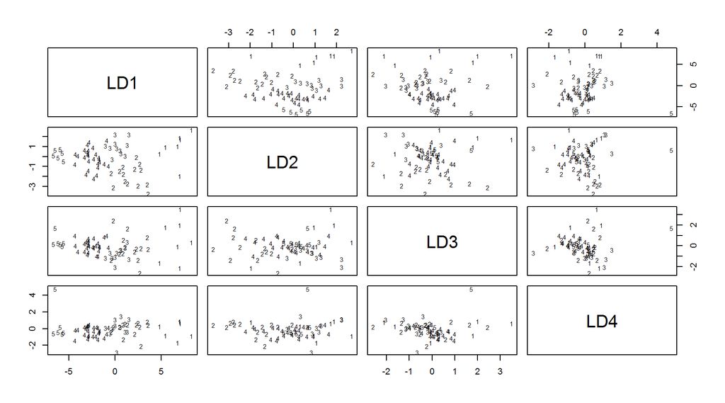

```r
plot(ldadat)
```

```r
rf = lda(CLASS ~ ., data, method = "moment")  #фиксируется модель для следующего задания
```

**Исправленная модель**:

```r
data %>% tbl_df()
```

| X1 | X2 | X3 | X4 | X5 | X6 | X7 | CLASS |
| --- | --- | --- | --- | --- | --- | --- | --- |
| 2174.0 | 9658 | 466.0 | 386.0 | 35.0 | 36.4 | 1756.0 | 1 |
| 274.0 | 10477 | 2321.0 | 767.0 | 56.0 | 35.6 | 7884.0 | 1 |
| -146.0 | 6567 | 713.0 | 581.0 | 74.0 | 13.8 | 1501.0 | 1 |
| -338.0 | 10282 | 499.0 | 764.0 | 51.0 | 30.2 | 1466.0 | 1 |
| -716.0 | 9316 | 677.0 | 533.0 | 109.0 | 20.5 | 1486.0 | 1 |
| 892.8 | 6425 | 944.0 | 1390.0 | 78.0 | 13.2 | 1936.0 | 1 |
| 191.0 | 5367 | 786.0 | 819.0 | 104.0 | 13.7 | 2011.0 | 2 |
| 0.0 | 6342 | 486.0 | 261.0 | 52.0 | 24.1 | 1841.0 | 2 |
| -107.0 | 5868 | 531.0 | 450.0 | 63.0 | 22.3 | 1608.0 | 2 |
| -903.0 | 6330 | 636.0 | 401.0 | 69.0 | 17.6 | 1768.0 | 2 |

[output cut: 55 more lines]

Ошибка нулевая, все данные отнесены правильно. *Правило, по которому наблюдение относится в ту или иную группу* примерно сделующее (если попробовать иерархический анализ):

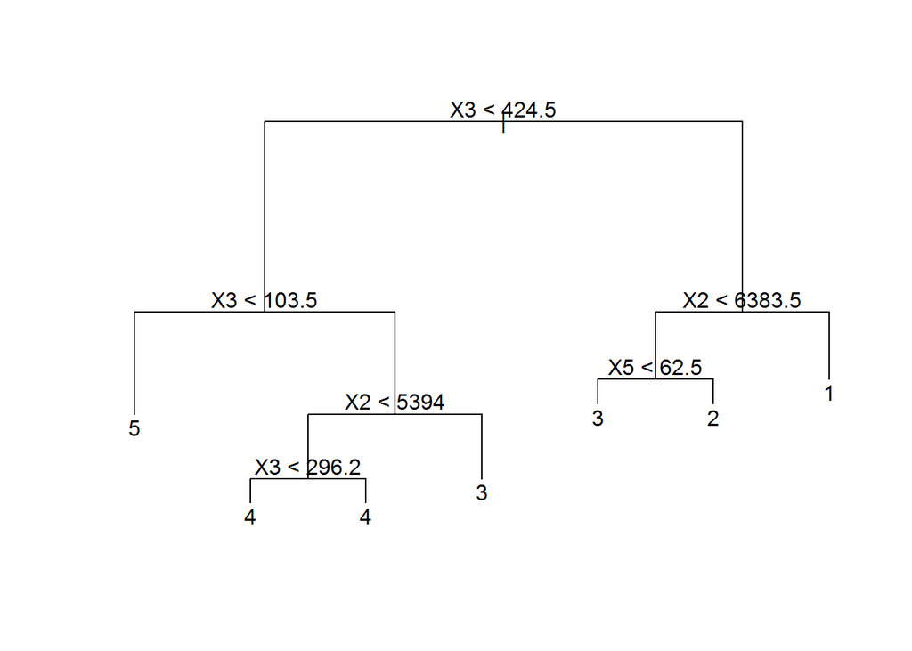

```r
library(tree)
datatree <- tree(data[, 8] ~ ., data[, -8])
plot(datatree)
text(datatree)
```